# Audio description quality: Systematic scoping review

Figure code

Dallı, H.; Jankowska, A.; Schrijver, I.; González Fernández, C. A.; Reviers, N.; Vercauteren, G.

Compiled 21 September 2026

# About this document

This document reproduces every figure in *Audio description quality: Systematic scoping review* that is drawn from data rather than from a drawing program. Knitting it end to end regenerates the published figures as both PDF and PNG in a `figures/` sub-folder, using only the two data appendices that accompany it.

**What is here.** Figures 2, 3, 5, 6, 7 and 8.

**What is not.** Figure 1 (the PRISMA 2020 flowchart) and Figure 4 (the pinwheel of the four dimensions) are diagrams rather than plots of charted data; they were drawn directly and have no code to report.

**Inputs.** Both files must sit in the same folder as this document:

| File | Contents |
| --- | --- |
| `APX3A_Cases_Studies.xlsx` | Appendix 3A — the 75 academic sources, one row per source |
| `APX3B_Cases_Guidelines.xlsx` | Appendix 3B — the 18 industry documents, one row per document |

Both appendices share a column-naming convention. A prefix in square brackets marks the block a column belongs to: `[BIB]` bibliographic metadata, `[MET]` study design, `[PAR]` describer and evaluator profiles, and `[COD]` the proportional coverage of each node of the AD Quality Dimensions framework — the percentage of that source’s material coded at the node — so a value of zero means the node was not coded in that source. The `[COD]` columns run parents first (Service, Script, Voice, Sound), then the thirteen children, then the grandchildren and great-grandchildren; the code below selects columns by name, never by position.

# Setup

```r
library(readxl)     # read the two .xlsx appendices
library(dplyr)      # data manipulation
library(tidyr)      # reshaping (pivot_longer, crossing, separate_longer_delim)
library(tibble)     # tribble(), tibble()
library(purrr)      # map_dbl(), pmap_dfr(), map_dfr()
library(stringr)    # str_detect(), str_remove()
library(forcats)    # fct_reorder()
library(readr)      # write_csv()
library(ggplot2)    # all figures
library(scales)     # axis labels, alpha(), rescale()
library(ggrepel)    # Figure 2 value labels
library(patchwork)  # Figure 3 panel composition
library(ggforce)    # Figure 7 node circles
```

```r
DATA_DIR <- "."
FIG_DIR  <- "figures"
dir.create(FIG_DIR, showWarnings = FALSE, recursive = TRUE)

find_appendix <- function(names) {
  candidates <- file.path(DATA_DIR, names)
  found <- candidates[file.exists(candidates)]
  if (!length(found)) {
    stop("Workbook not found. Looked for:\n  ", paste(candidates, collapse = "\n  "))
  }
  found[1]
}

APX_A <- find_appendix(c("APX3A_Cases_Studies.xlsx"))        # academic studies
APX_B <- find_appendix(c("APX3B_Cases_Guidelines.xlsx"))     # industry guidelines
```

## Typography and output devices

The published figures are set in Gill Sans MT. `pick_font()` uses it when the system has it and falls back to the graphics device’s default family otherwise, so the document knits on any machine.

```r
pick_font <- function(preferred = "Gill Sans MT") {
  installed <- tryCatch(
    unique(systemfonts::system_fonts()$family),
    error = function(e) character(0)
  )
  if (preferred %in% installed) preferred else ""   # "" = device default
}

FONT <- pick_font()

# cairo_pdf embeds the font and handles transparency; plain pdf() is the
# fallback on builds of R compiled without cairo support.
PDF_DEVICE <- if (isTRUE(capabilities("cairo"))) grDevices::cairo_pdf else grDevices::pdf

save_figure <- function(plot, stem, width, height,
                        png_width = width, png_height = height, dpi = 900) {
  ggsave(file.path(FIG_DIR, paste0(stem, ".pdf")), plot,
         device = PDF_DEVICE, width = width, height = height, units = "in")
  ggsave(file.path(FIG_DIR, paste0(stem, ".png")), plot,
         device = "png", dpi = dpi, bg = "white",
         width = png_width, height = png_height, units = "in")
  invisible(file.path(FIG_DIR, stem))
}
```

## Palette

One palette runs through every figure. The four dimension hues are taken from the Okabe-Ito colourblind-safe set and always carry the same meaning: amber is Service, blue Script, green Voice, pink Sound. The saturated variant fills marks, the dark variant sets type on white. Where a figure contrasts the two disciplines instead of the four dimensions, it reuses the Script blue for translation studies and the Service amber for computer science.

```r
DIM_SAT <- c(SERVICE = "#E69F00", SCRIPT = "#0072B2",
             VOICE   = "#009E73", SOUND  = "#CC79A7")

DIM_DARK <- c(SERVICE = "#9E6400", SCRIPT = "#004F80",
              VOICE   = "#006B4E", SOUND  = "#7A2E5A")

DIM_LITE <- c(SERVICE = "#FDE8B0", SCRIPT = "#C5E3F2",
              VOICE   = "#B2EAD8", SOUND  = "#F4DBF0")

COL_TS <- "#0072B2"   # translation studies
COL_CS <- "#E69F00"   # computer science
```

## Reading the appendices

`to_num()` is the one piece of defensive parsing the pipeline needs: a handful of cells in Appendix 3B were entered on a locale that writes decimals with a comma (`0,00`), and they are read as text. Converting the separator before `as.numeric()` keeps those cells numeric without editing the appendix itself.

```r
to_num <- function(x) {
  suppressWarnings(as.numeric(gsub(",", ".", as.character(x))))
}

studies    <- read_excel(APX_A)   # Appendix 3A
guidelines <- read_excel(APX_B)   # Appendix 3B

# Node names in the framework's own vocabulary: four parents, thirteen children.
PARENTS <- c("SERVICE", "SCRIPT", "VOICE", "SOUND")

CHILDREN_BY_PARENT <- list(
  SERVICE = c("COMMISSIONING", "ACCESS-TO-ACCESS", "PRE-SHOW ACCESS",
              "AUGMENTED ACCESS", "QUALITY ASSURANCE"),
  SCRIPT  = c("CONTENT", "LANGUAGE", "TIMING", "SKOPOS"),
  VOICE   = c("ARTICULATION", "PERFORMANCE"),
  SOUND   = c("FIDELITY", "MIXING")
)

# Human-readable labels for the child nodes, used in figure axes and legends.
CHILD_LABELS <- c(
  COMMISSIONING       = "Commissioning",
  `ACCESS-TO-ACCESS`  = "Access-to-access",
  `PRE-SHOW ACCESS`   = "Pre-show access",
  `AUGMENTED ACCESS`  = "Augmented access",
  `QUALITY ASSURANCE` = "Quality assurance",
  CONTENT             = "Content",
  LANGUAGE            = "Language",
  TIMING              = "Timing",
  SKOPOS              = "Skopos",
  ARTICULATION        = "Articulation",
  PERFORMANCE         = "Performance",
  FIDELITY            = "Fidelity",
  MIXING              = "Mixing"
)

# Which parent each child belongs to, derived from the list rather than retyped.
PARENT_OF <- setNames(
  rep(names(CHILDREN_BY_PARENT), lengths(CHILDREN_BY_PARENT)),
  unlist(CHILDREN_BY_PARENT, use.names = FALSE)
)

cat(nrow(studies), "academic sources;", nrow(guidelines), "industry documents\n")
```

```
## 75 academic sources; 18 industry documents
```

```r
# Fail early and legibly if an expected coding column is absent, rather than
# producing a figure with a silently empty node.
needed <- paste0("[COD] ", c(PARENTS, unlist(CHILDREN_BY_PARENT, use.names = FALSE)))
missing_a <- setdiff(needed, names(studies))
missing_b <- setdiff(needed, names(guidelines))
if (length(missing_a) || length(missing_b)) {
  stop("Coding columns not found:\n  3A: ", paste(missing_a, collapse = ", "),
       "\n  3B: ", paste(missing_b, collapse = ", "))
}
cat("All", length(needed), "parent and child coding columns present in both appendices.\n")
```

```
## All 17 parent and child coding columns present in both appendices.
```

`discipline_of()` collapses the `[BIB] Discipline` column into the two disciplines the article compares. Everything else — communication studies, disability studies, anthropology — becomes `"Other"`, and unassigned rows become `NA` so that they drop out of comparisons rather than forming a spurious category.

```r
discipline_of <- function(x) {
  dplyr::case_when(
    grepl("translation", x, ignore.case = TRUE) ~ "Translation studies",
    grepl("computer",    x, ignore.case = TRUE) ~ "Computer science",
    is.na(x) | x == "Unassigned"                ~ NA_character_,
    TRUE                                        ~ "Other"
  )
}
```

# Figure 2 — Inter-rater agreement

The two reference lines mark the conventional Landis and Koch (1977) thresholds. They are drawn with `geom_hline()`, which produces no legend key of its own, so an invisible `geom_line()` layer (`colour = NA`) is added purely to give the legend engine something to build a “Threshold” key from.

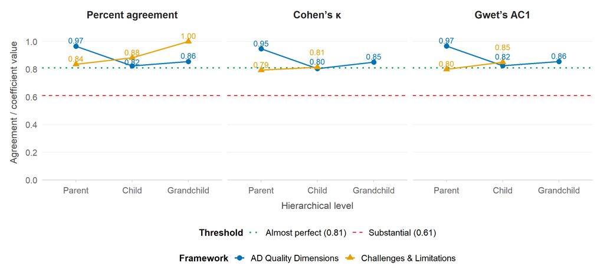

```r
BASE_F2 <- 15

irr <- tribble(
  ~Framework,                 ~Level,       ~PA,   ~Kappa, ~AC1,
  "AD Quality Dimensions",    "Parent",     0.966, 0.947,  0.967,
  "AD Quality Dimensions",    "Child",      0.824, 0.804,  0.825,
  "AD Quality Dimensions",    "Grandchild", 0.856, 0.851,  0.856,
  "Challenges & Limitations", "Parent",     0.836, 0.793,  0.800,
  "Challenges & Limitations", "Child",      0.882, 0.814,  0.851,
  "Challenges & Limitations", "Grandchild", 1.000, NA,     NA
) |>
  mutate(
    Level     = factor(Level, levels = c("Parent", "Child", "Grandchild")),
    Framework = factor(Framework, levels = c("AD Quality Dimensions",
                                             "Challenges & Limitations"))
  ) |>
  pivot_longer(c(PA, Kappa, AC1), names_to = "Metric", values_to = "Value") |>
  mutate(Metric = factor(
    Metric,
    levels = c("PA", "Kappa", "AC1"),
    labels = c("Percent agreement", "Cohen’s κ", "Gwet’s AC1")
  ))

thresholds <- tibble(
  yintercept = c(0.61, 0.81),
  label      = c("Substantial (0.61)", "Almost perfect (0.81)")
)

fig2 <- ggplot(irr, aes(x = Level, y = Value,
                        colour = Framework, group = Framework)) +
  geom_hline(yintercept = 0.61, linetype = "dashed",
             colour = "#E50914", linewidth = 0.7, inherit.aes = FALSE) +
  geom_hline(yintercept = 0.81, linetype = "dotted",
             colour = "#03A860", linewidth = 1.0, inherit.aes = FALSE) +
  # Invisible layer: exists only so the threshold lines acquire a legend key.
  geom_line(data = thresholds,
            aes(x = 1, y = yintercept, linetype = label, linewidth = label),
            colour = NA, inherit.aes = FALSE) +
  scale_linetype_manual(
    name   = "Threshold",
    values = c("Substantial (0.61)" = "dashed",
               "Almost perfect (0.81)" = "dotted"),
    guide  = guide_legend(order = 1,
                          override.aes = list(colour    = c("#03A860", "#E50914"),
                                              linewidth = c(1.0, 0.7)))
  ) +
  scale_linewidth_manual(
    name   = "Threshold",
    values = c("Substantial (0.61)" = 0.55, "Almost perfect (0.81)" = 1.30),
    guide  = "none"
  ) +
  geom_line(linewidth = 0.90, alpha = 0.90, na.rm = TRUE) +
  geom_point(aes(shape = Framework), size = 3.2, stroke = 0.55, na.rm = TRUE) +
  geom_text_repel(
    aes(label = ifelse(is.na(Value), "", sprintf("%.2f", Value)),
        colour = Framework),
    size = BASE_F2 * 0.26, family = FONT, show.legend = FALSE, na.rm = TRUE,
    nudge_y = 0.028,          # lift labels clear of the marker first
    direction = "y",          # then let them repel vertically only
    segment.size = 0.30, segment.color = "grey65", segment.alpha = 0.70,
    min.segment.length = 0.15, box.padding = 0.18, point.padding = 0.20,
    force = 1.2, max.iter = 3000, max.overlaps = Inf
  ) +
  facet_wrap(~Metric, nrow = 1) +
  scale_colour_manual(
    name   = "Framework",
    values = c("AD Quality Dimensions" = DIM_SAT[["SCRIPT"]],
               "Challenges & Limitations" = DIM_SAT[["SERVICE"]]),
    guide  = guide_legend(order = 2,
                          override.aes = list(linewidth = 1.0, size = 3.2))
  ) +
  scale_shape_manual(
    name   = "Framework",
    values = c("AD Quality Dimensions" = 16, "Challenges & Limitations" = 17),
    guide  = guide_legend(order = 2)
  ) +
  scale_y_continuous(
    name   = "Agreement / coefficient value",
    limits = c(0, 1.12), breaks = seq(0, 1, 0.2),
    labels = label_number(accuracy = 0.1),
    expand = expansion(mult = c(0, 0))
  ) +
  scale_x_discrete(name = "Hierarchical level") +
  theme_minimal(base_size = BASE_F2, base_family = FONT) +
  theme(
    panel.grid.minor   = element_blank(),
    panel.grid.major.x = element_blank(),
    panel.grid.major.y = element_line(colour = "grey92", linewidth = 0.32),
    axis.line.x        = element_line(colour = "grey75", linewidth = 0.30),
    axis.ticks.x       = element_line(colour = "grey75", linewidth = 0.30),
    axis.ticks.length  = unit(3, "pt"),
    axis.title.x       = element_text(size = BASE_F2 * 0.90, colour = "grey30",
                                      margin = margin(t = 10)),
    axis.title.y       = element_text(size = BASE_F2 * 0.90, colour = "grey30",
                                      margin = margin(r = 10)),
    axis.text          = element_text(size = BASE_F2 * 0.82, colour = "grey40"),
    strip.text         = element_text(face = "bold", size = BASE_F2 * 0.95,
                                      colour = "grey15", margin = margin(b = 8)),
    legend.position    = "bottom",
    legend.box         = "vertical",
    legend.spacing.y   = unit(0.15, "cm"),
    legend.title       = element_text(face = "bold", size = BASE_F2 * 0.88),
    legend.text        = element_text(size = BASE_F2 * 0.82),
    plot.background    = element_rect(fill = "white", colour = NA),
    plot.margin        = margin(14, 16, 10, 14)
  )

save_figure(fig2, "Figure2", width = 12, height = 5.5)
fig2
```

# Figure 3 — Corpus profile

Three panels over the academic strand of the corpus: publications per year by discipline, AD modality within each discipline, and the split between empirical and theoretical work. `Unassigned` is treated as missing throughout, so a source with no recorded modality is left out of the modality panel rather than counted as an extra category.

```r
BASE_F3 <- 17

corpus <- studies |>
  mutate(
    pub_year   = to_num(`[BIB] Publication Year`),
    discipline = discipline_of(`[BIB] Discipline`),
    modality   = if_else(`[BIB] AD Modality` == "Unassigned" |
                           is.na(`[BIB] AD Modality`),
                         NA_character_, `[BIB] AD Modality`),
    study_type = if_else(`[MET] Study Type` == "Unassigned" |
                           is.na(`[MET] Study Type`),
                         NA_character_, `[MET] Study Type`)
  )
```

```r
# One theme shared by the three panels, so they read as a single figure.
theme_corpus <- function() {
  theme_minimal(base_size = BASE_F3, base_family = FONT) +
    theme(
      panel.grid.minor  = element_blank(),
      panel.grid.major  = element_line(colour = "grey92", linewidth = 0.32),
      axis.line         = element_line(colour = "grey75", linewidth = 0.30),
      axis.ticks        = element_line(colour = "grey75", linewidth = 0.30),
      axis.ticks.length = unit(3, "pt"),
      axis.title        = element_text(size = BASE_F3 * 0.88, colour = "grey30",
                                       margin = margin(t = 8, r = 8)),
      axis.text         = element_text(size = BASE_F3 * 0.80, colour = "grey40"),
      legend.text       = element_text(size = BASE_F3 * 0.78),
      legend.title      = element_text(size = BASE_F3 * 0.82, face = "bold"),
      legend.key.size   = unit(0.45, "cm"),
      plot.title        = element_text(size = BASE_F3 * 0.95, face = "bold",
                                       colour = "grey15", margin = margin(b = 6)),
      plot.background   = element_rect(fill = "white", colour = NA),
      plot.margin       = margin(10, 12, 10, 10)
    )
}
```

**Left panel.** Grey bars give the yearly total across the whole academic strand; the two lines pick out the two dominant disciplines, so the gap between the bars and the lines is everything else.

```r
year_total <- corpus |>
  filter(!is.na(pub_year)) |>
  count(pub_year, name = "n_total")

year_discipline <- corpus |>
  filter(!is.na(pub_year),
         discipline %in% c("Translation studies", "Computer science")) |>
  count(pub_year, discipline, name = "n") |>
  mutate(discipline = factor(discipline,
                             levels = c("Translation studies", "Computer science")))

p_years <- ggplot() +
  geom_col(data = year_total, aes(x = pub_year, y = n_total),
           fill = "grey88", width = 0.75) +
  geom_line(data = year_discipline, aes(x = pub_year, y = n, colour = discipline),
            linewidth = 1.10) +
  geom_point(data = year_discipline, aes(x = pub_year, y = n, colour = discipline),
             size = 2.2, fill = "white", shape = 21, stroke = 1.2) +
  scale_colour_manual(values = c("Translation studies" = COL_TS,
                                 "Computer science"    = COL_CS),
                      name = "Discipline") +
  scale_x_continuous(name = "Year", breaks = pretty_breaks(6)) +
  scale_y_continuous(name = "Publications",
                     expand = expansion(mult = c(0, 0.10)),
                     breaks = pretty_breaks(5)) +
  theme_corpus() +
  theme(legend.position = "bottom", legend.title = element_blank())
```

**Middle panel.** Modality shares within each discipline. Proportions are computed per discipline, so each bar sums to 100% and the two are comparable despite very different denominators. Long modality names are broken over two lines for the legend.

```r
MODALITY_COLS <- c(
  "Pre-recorded\n(screen)"              = DIM_SAT[["SCRIPT"]],
  "Mixed"                               = DIM_SAT[["SERVICE"]],
  "Pre-recorded\n(architecture/museum)" = DIM_SAT[["VOICE"]],
  "Live"                                = DIM_SAT[["SOUND"]]
)

discipline_modality <- corpus |>
  filter(!is.na(discipline), !is.na(modality), discipline != "Other") |>
  count(discipline, modality, name = "n") |>
  group_by(discipline) |>
  mutate(prop = n / sum(n)) |>
  ungroup() |>
  mutate(
    discipline = factor(discipline,
                        levels = c("Translation studies", "Computer science")),
    modality   = recode(
      modality,
      "Pre-recorded (screen)"              = "Pre-recorded\n(screen)",
      "Pre-recorded (architecture/museum)" = "Pre-recorded\n(architecture/museum)"
    ),
    modality   = factor(modality, levels = names(MODALITY_COLS))
  )

p_modality <- ggplot(discipline_modality, aes(x = discipline, y = prop, fill = modality)) +
  geom_col(width = 0.72, colour = "white", linewidth = 0.4) +
  facet_wrap(~discipline, nrow = 1, scales = "free_x",
             labeller = labeller(discipline = label_wrap_gen(width = 12))) +
  scale_y_continuous(name = "Share of studies",
                     labels = percent_format(accuracy = 1),
                     expand = expansion(mult = c(0, 0.02)),
                     breaks = seq(0, 1, 0.25)) +
  scale_x_discrete(labels = NULL, breaks = NULL) +
  scale_fill_manual(values = MODALITY_COLS, name = "AD Modality",
                    guide = guide_legend(ncol = 2)) +
  theme_corpus() +
  theme(
    axis.title.x      = element_blank(),
    axis.line.x       = element_blank(),
    axis.ticks.x      = element_blank(),
    strip.text        = element_text(face = "bold", size = BASE_F3 * 0.85,
                                     colour = "grey15",
                                     margin = margin(b = 8, t = 4)),
    strip.clip        = "off",
    legend.position   = "bottom",
    legend.title      = element_text(size = BASE_F3 * 0.82, face = "bold",
                                     hjust = 0.5),
    legend.key.height = unit(0.55, "cm"),
    legend.text       = element_text(size = BASE_F3 * 0.72, lineheight = 0.85)
  )
```

**Right panel.** Counts of empirical and theoretical studies, ordered by size.

```r
TYPE_COLS <- c("Empirical" = DIM_SAT[["SCRIPT"]], "Theoretical" = DIM_SAT[["SERVICE"]])

study_types <- corpus |>
  filter(!is.na(study_type)) |>
  count(study_type, name = "n") |>
  mutate(study_type = fct_reorder(study_type, n))

p_type <- ggplot(study_types, aes(y = study_type, x = n, fill = study_type)) +
  geom_col(width = 0.55, colour = "white") +
  geom_text(aes(label = n), hjust = -0.35, size = BASE_F3 * 0.28,
            colour = "grey30", family = FONT) +
  scale_fill_manual(values = TYPE_COLS, guide = "none") +
  scale_x_continuous(name = "Number of studies",
                     expand = expansion(mult = c(0, 0.14)),
                     breaks = pretty_breaks(5)) +
  scale_y_discrete(name = NULL) +
  theme_corpus() +
  theme(axis.line.y = element_blank(), axis.ticks.y = element_blank())
```

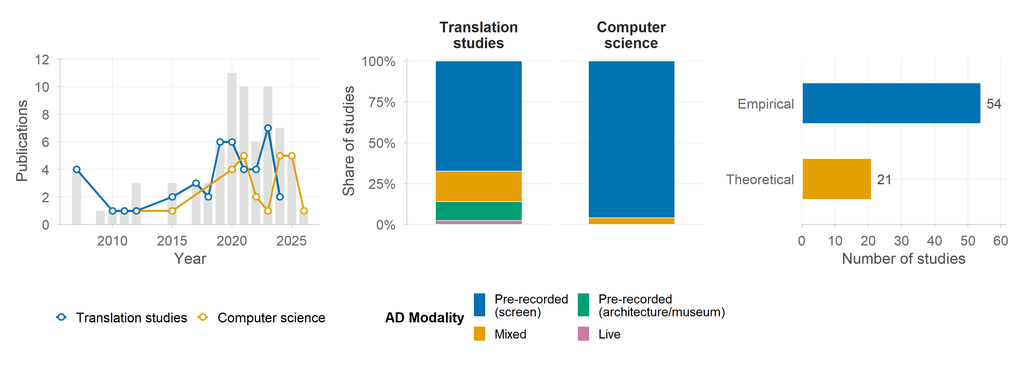

```r
fig3 <- p_years + p_modality + p_type +
  plot_layout(ncol = 3, widths = c(1.4, 1.6, 1.1)) &
  theme(plot.background = element_rect(fill = "white", colour = NA))

save_figure(fig3, "Figure3", width = 14, height = 5)
fig3
```

# Figure 5 — Parent-level prevalence, academic against industry

A dumbbell plot. Each row is one of the four dimensions; the two markers are the share of sources in each corpus that code that dimension at all, and the connector is the distance between them. Corpus is encoded by marker *style* — filled for academic, hollow for industry — never by colour, so that colour can stay reserved for the dimension. Rows are ordered by pooled prevalence, least prevalent at the bottom.

```r
BASE_F5 <- 12
W_F5 <- 8; H_F5 <- 4.6

GUIDE_COL <- "grey93"   # row guides
VALUE_COL <- "grey45"   # the two percentages on each row

# Device family, and the same fallback the rest of the document uses.
DEV_FAMILY_F5 <- if (nzchar(FONT)) FONT else "sans"

# Share of sources in a corpus that code a given node above zero.
share <- function(data, node) {
  sum(to_num(data[[paste0("[COD] ", node)]]) > 0, na.rm = TRUE) / nrow(data) * 100
}

prev <- tibble(dim = PARENTS) |>
  mutate(
    acad     = map_dbl(dim, ~ share(studies, .x)),
    industry = map_dbl(dim, ~ share(guidelines, .x)),
    pooled   = map_dbl(dim, function(node) {
      pooled_values <- c(to_num(studies[[paste0("[COD] ", node)]]),
                         to_num(guidelines[[paste0("[COD] ", node)]]))
      sum(pooled_values > 0, na.rm = TRUE) /
        (nrow(studies) + nrow(guidelines)) * 100
    })
  ) |>
  arrange(pooled) |>                      # most prevalent ends up on top
  mutate(y = row_number(), lo = pmin(acad, industry), hi = pmax(acad, industry),
         sat = DIM_SAT[dim], dark = DIM_DARK[dim])

knitr::kable(
  prev |> select(Dimension = dim, Academic = acad,
                 Industry = industry, Pooled = pooled),
  digits = 1, caption = "Prevalence (% of sources coding the dimension)"
)
```

Prevalence (% of sources coding the dimension)

| Dimension | Academic | Industry | Pooled |
| --- | --- | --- | --- |
| SOUND | 33.3 | 38.9 | 34.4 |
| VOICE | 50.7 | 33.3 | 47.3 |
| SERVICE | 61.3 | 61.1 | 61.3 |
| SCRIPT | 85.3 | 83.3 | 84.9 |

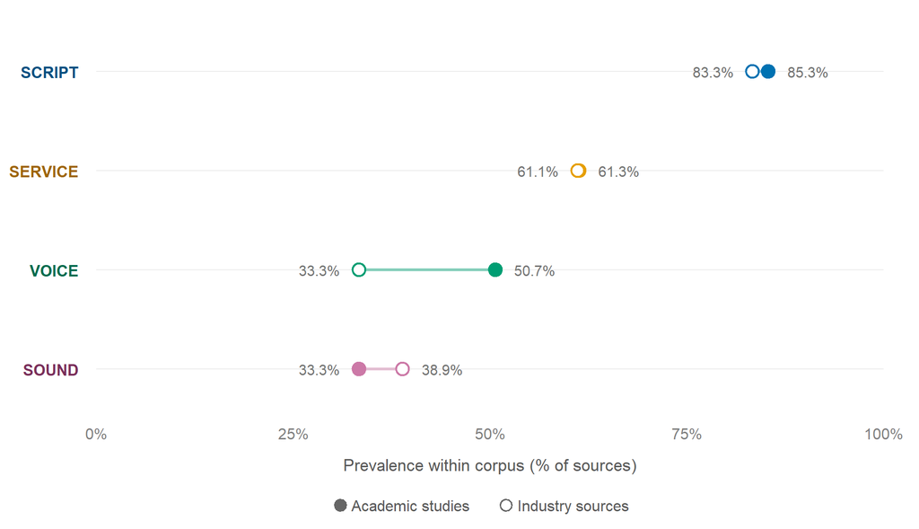

```r
write_csv(prev |> select(dim, acad, industry, pooled),
          file.path(FIG_DIR, "Figure5_summary.csv"))

SOURCE_LEVELS <- c("Academic studies", "Industry sources")

pts <- prev |>
  select(dim, y, sat, acad, industry) |>
  pivot_longer(c(acad, industry), names_to = "src", values_to = "x") |>
  mutate(
    source = factor(if_else(src == "acad", SOURCE_LEVELS[1], SOURCE_LEVELS[2]),
                    levels = SOURCE_LEVELS),
    # Identity-mapped: the dimension's colour when filled, white when hollow.
    fill = if_else(src == "acad", sat, "white")
  )

PAD <- 2.4     # gap between a marker and its value, in % units
vals <- bind_rows(
  prev |> transmute(y, x = lo - PAD, hjust = 1, label = sprintf("%.1f%%", lo)),
  prev |> transmute(y, x = hi + PAD, hjust = 0, label = sprintf("%.1f%%", hi))
)

NAME_SIZE   <- 3.5   # dimension names, in ggplot text units (about 10 pt)
NAME_GAP_MM <- 4     # gap between a name and the 0% end of its row guide

theme_dumbbell <- theme_minimal(base_size = BASE_F5, base_family = FONT) +
  theme(
    panel.grid        = element_blank(),
    axis.ticks        = element_blank(),
    axis.text.y       = element_blank(),
    axis.title.y      = element_blank(),
    axis.text.x       = element_text(size = 9.5, colour = "grey50",
                                     margin = margin(t = 6)),
    axis.title.x      = element_text(size = 10.5, colour = "grey35",
                                     margin = margin(t = 10)),
    legend.position      = "bottom",
    legend.justification = "center",
    legend.direction     = "horizontal",
    legend.title         = element_blank(),
    legend.text          = element_text(size = 9.5, colour = "grey35",
                                        margin = margin(r = 12, l = 2)),
    legend.key.width  = unit(10, "pt"),
    legend.key.height = unit(10, "pt"),
    legend.margin     = margin(0, 0, 0, 0),
    legend.box.spacing = unit(14, "pt"),
    plot.background   = element_rect(fill = "white", colour = NA)
  )

# The plot is built twice: once to measure it, once with the reserved margin.
base_plot <- function(left_pt) {
  ggplot() +
    geom_segment(data = prev, aes(x = 0, xend = 100, y = y, yend = y),
                 colour = GUIDE_COL, linewidth = .35) +
    # Connector softened, so the markers carry the reading.
    geom_segment(data = prev,
                 aes(x = acad, xend = industry, y = y, yend = y, colour = sat),
                 linewidth = .9, alpha = .45, lineend = "round") +
    geom_point(data = pts, aes(x, y, shape = source, fill = fill, colour = sat),
               size = 3.4, stroke = .9) +
    geom_text(data = vals, aes(x, y, label = label, hjust = hjust),
              vjust = .5, size = 3.2, colour = VALUE_COL, family = FONT) +
    # Both corpora use shape 21; openness comes from the fill, and the legend
    # keys are overridden to neutral grey so they read as style, not dimension.
    scale_shape_manual(
      values = c("Academic studies" = 21, "Industry sources" = 21),
      guide  = guide_legend(override.aes = list(
        fill = c("grey40", "white"), colour = "grey40", size = 3, stroke = .8))
    ) +
    scale_fill_identity() + scale_colour_identity() +
    scale_x_continuous(name = "Prevalence within corpus (% of sources)",
                       breaks = seq(0, 100, 25),
                       labels = paste0(seq(0, 100, 25), "%"),
                       expand = expansion(0)) +
    scale_y_continuous(expand = expansion(0)) +
    # Limits live on the coordinate system, so the names set left of 0% are
    # not treated as out-of-range data and dropped.
    coord_cartesian(xlim = c(0, 100), ylim = c(.5, nrow(prev) + .5),
                    expand = FALSE, clip = "off") +
    theme_dumbbell + theme(plot.margin = margin(14, 22, 10, left_pt))
}

# Measure the names in the output font on the kind of device used for the
# output, reserve that much room on the left, then convert the physical gap
# into % units so the result is independent of the figure's size.
tmp_dev <- tempfile(fileext = ".pdf")
PDF_DEVICE(tmp_dev, width = W_F5, height = H_F5, family = DEV_FAMILY_F5)
text_w_mm <- function(d) {
  grob <- grid::textGrob(d, gp = grid::gpar(fontfamily = FONT, fontface = "bold",
                                            fontsize = NAME_SIZE * .pt))
  grid::convertWidth(grid::grobWidth(grob), "mm", valueOnly = TRUE)
}
name_w_mm <- max(map_dbl(prev$dim, text_w_mm))
left_pt <- (name_w_mm + NAME_GAP_MM + 2) * 72.27 / 25.4
g <- ggplotGrob(base_plot(left_pt))
panel_w_mm <- W_F5 * 25.4 - grid::convertWidth(sum(g$widths), "mm", valueOnly = TRUE)
invisible(grDevices::dev.off()); unlink(tmp_dev)
gap_units <- NAME_GAP_MM / (panel_w_mm / 100)

fig5 <- base_plot(left_pt) +
  annotate("text", x = -gap_units, y = prev$y, label = prev$dim,
           colour = prev$dark, hjust = 1, vjust = .5,
           size = NAME_SIZE, fontface = "bold", family = FONT)

draw_fig5 <- function() print(fig5)
PDF_DEVICE(file.path(FIG_DIR, "Figure5.pdf"), width = W_F5, height = H_F5,
           family = DEV_FAMILY_F5)
draw_fig5(); invisible(grDevices::dev.off())
grDevices::png(file.path(FIG_DIR, "Figure5.png"), width = W_F5, height = H_F5,
               units = "in", res = 900, type = "cairo", bg = "white")
draw_fig5(); invisible(grDevices::dev.off())

fig5
```

# Figure 6 — Child-level prevalence by discipline

A radar chart over the thirteen child nodes, drawn by hand in Cartesian coordinates rather than with `coord_polar()`, which gives direct control over where each spoke sits. The thirteen spokes are evenly spaced clockwise from the top, but grouped: the four Script children occupy the top right, Voice the bottom right, Sound the bottom left, and the five Service children the top left, with a colored arc drawn over each group’s span. This follows the ordering in the pinwheel diagram (Figure 4).

```r
BASE_F6 <- 14

# Node order around the wheel, clockwise from the top.
WHEEL <- c(
  CHILDREN_BY_PARENT$SCRIPT,    # positions 1-4,  top right
  "PERFORMANCE", "ARTICULATION",# positions 5-6,  bottom right (Voice)
  "MIXING", "FIDELITY",         # positions 7-8,  bottom left  (Sound)
  "AUGMENTED ACCESS", "ACCESS-TO-ACCESS", "QUALITY ASSURANCE",
  "COMMISSIONING", "PRE-SHOW ACCESS"   # positions 9-13, top left (Service)
)
stopifnot(setequal(WHEEL, unlist(CHILDREN_BY_PARENT, use.names = FALSE)))

n_axes   <- length(WHEEL)
ROTATION <- -pi / n_axes   # half a step clockwise; set to 0 to remove

axis_angles <- tibble(
  child = factor(WHEEL, levels = WHEEL),
  angle = seq(pi / 2, pi / 2 - 2 * pi,
              length.out = n_axes + 1)[-(n_axes + 1)] + ROTATION,
  parent = PARENT_OF[WHEEL]
)

# Arc over each parent group, extended slightly past its outer spokes.
ARC_RADIUS <- 1.08
group_span <- axis_angles |>
  group_by(parent) |>
  summarise(start = min(angle), end = max(angle), .groups = "drop")

arc_guides <- group_span |>
  pmap_dfr(function(parent, start, end) {
    pad <- (end - start) * 0.08
    tidyr::crossing(parent = parent,
                    t = seq(start - pad, end + pad, length.out = 150)) |>
      mutate(x = cos(t) * ARC_RADIUS, y = sin(t) * ARC_RADIUS)
  })
```

```r
by_discipline <- studies |>
  mutate(discipline = discipline_of(`[BIB] Discipline`)) |>
  filter(discipline %in% c("Translation studies", "Computer science"))

child_prev <- by_discipline |>
  select(discipline, all_of(paste0("[COD] ", WHEEL))) |>
  mutate(across(-discipline, to_num)) |>
  group_by(discipline) |>
  summarise(across(everything(), ~ mean(.x > 0, na.rm = TRUE)), .groups = "drop") |>
  rename_with(~ sub("^\\[COD\\] ", "", .x), -discipline) |>
  pivot_longer(-discipline, names_to = "child", values_to = "prop") |>
  mutate(
    child      = factor(child, levels = WHEEL),
    discipline = factor(discipline,
                        levels = c("Translation studies", "Computer science"))
  )
```

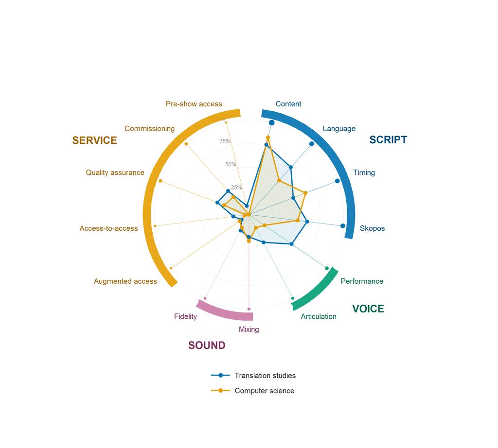

```r
# Polygon vertices; the first row is repeated at the end to close the shape.
radar_polygons <- child_prev |>
  left_join(select(axis_angles, child, angle), by = "child") |>
  mutate(x = prop * cos(angle), y = prop * sin(angle)) |>
  group_by(discipline) |>
  group_modify(~ bind_rows(.x, .x[1, ])) |>
  ungroup()

grid_rings <- tidyr::crossing(r = c(0.25, 0.50, 0.75, 1.0),
                              t = seq(0, 2 * pi, length.out = 300)) |>
  mutate(x = r * cos(t), y = r * sin(t))

spokes <- axis_angles |>
  mutate(x0 = 0, y0 = 0, x1 = cos(angle), y1 = sin(angle),
         spoke_col = DIM_SAT[parent])

# Rim dots, sized by the mean of the two disciplines' prevalence.
rim_dots <- child_prev |>
  group_by(child) |>
  summarise(mean_prev = mean(prop), .groups = "drop") |>
  left_join(select(axis_angles, child, angle, parent), by = "child") |>
  mutate(x = cos(angle), y = sin(angle),
         dot_col  = DIM_SAT[parent],
         dot_size = rescale(mean_prev, to = c(1.5, 4.0)))

# Child labels sit at a fixed radius; alignment flips with the quadrant so
# text always reads outwards.
LABEL_RADIUS <- 1.18
child_label_pos <- axis_angles |>
  mutate(
    child = as.character(child),
    label = CHILD_LABELS[child],
    col   = DIM_DARK[parent],
    x     = LABEL_RADIUS * cos(angle),
    y     = LABEL_RADIUS * sin(angle),
    hjust = case_when(cos(angle) >  0.15 ~ 0, cos(angle) < -0.15 ~ 1, TRUE ~ 0.5),
    vjust = case_when(sin(angle) >  0.15 ~ 0, sin(angle) < -0.15 ~ 1, TRUE ~ 0.5)
  )

# Parent labels sit further out, at the mid-angle of their group. The two
# nudge vectors are the only hand-tuning in the figure: Service has an odd
# number of children, so its midpoint falls on the "Quality assurance" spoke
# and has to be slid into the gap beside it; Sound is pulled in slightly.
PARENT_RADIUS   <- 1.48
PARENT_R_NUDGE  <- c(SERVICE =  0.10, SCRIPT =  0.00, VOICE = -0.03, SOUND = -0.12)
PARENT_ANG_NUDGE <- c(SERVICE = -0.13, SCRIPT = -0.07, VOICE =  0.13, SOUND =  0.06)

parent_label_pos <- axis_angles |>
  group_by(parent) |>
  summarise(mid_angle = atan2(mean(sin(angle)), mean(cos(angle))), .groups = "drop") |>
  mutate(
    col = DIM_DARK[parent],
    r   = PARENT_RADIUS + unname(PARENT_R_NUDGE[parent]),
    ang = mid_angle     + unname(PARENT_ANG_NUDGE[parent]),
    x   = r * cos(ang),
    y   = r * sin(ang),
    # Alignment keys off the un-nudged midpoint, so retuning the offsets
    # cannot flip a label from right-aligned to centred.
    hjust = case_when(cos(mid_angle) >  0.15 ~ 0,
                      cos(mid_angle) < -0.15 ~ 1, TRUE ~ 0.5),
    vjust = case_when(sin(mid_angle) >  0.15 ~ 0,
                      sin(mid_angle) < -0.15 ~ 1, TRUE ~ 0.5)
  )

# Ring percentages are anchored to the top-left spoke so they read outwards.
ref_angle   <- axis_angles$angle[axis_angles$child == "PRE-SHOW ACCESS"]
grid_labels <- tibble(
  r = c(0.25, 0.50, 0.75, 1.0), label = c("25%", "50%", "75%", "100%"),
  x = (r + 0.05) * cos(ref_angle), y = (r + 0.05) * sin(ref_angle)
)

discipline_line <- c("Translation studies" = COL_TS, "Computer science" = COL_CS)
discipline_fill <- c("Translation studies" = alpha(COL_TS, 0.10),
                     "Computer science"    = alpha(COL_CS, 0.10))

LEGEND_X <- -0.40   # single knob for the manual legend's horizontal position

fig6 <- ggplot() +
  geom_path(data = grid_rings, aes(x = x, y = y, group = r),
            colour = "grey91", linewidth = 0.28) +
  geom_text(data = grid_labels, aes(x = x, y = y, label = label),
            size = BASE_F6 * 0.20, colour = "grey55", family = FONT, hjust = 1) +
  geom_segment(data = spokes,
               aes(x = x0, y = y0, xend = x1, yend = y1, colour = I(spoke_col)),
               linewidth = 0.38, alpha = 0.50) +
  geom_path(data = arc_guides,
            aes(x = x, y = y, group = parent, colour = I(DIM_SAT[parent])),
            linewidth = 5.5, lineend = "butt", alpha = 0.90) +
  geom_point(data = rim_dots,
             aes(x = x, y = y, fill = I(dot_col), size = I(dot_size)),
             shape = 21, colour = "white", stroke = 0.6, show.legend = FALSE) +
  geom_polygon(data = radar_polygons,
               aes(x = x, y = y, group = discipline,
                   fill = I(discipline_fill[as.character(discipline)])),
               show.legend = FALSE) +
  geom_path(data = radar_polygons,
            aes(x = x, y = y, group = discipline,
                colour = I(discipline_line[as.character(discipline)])),
            linewidth = 0.90, lineend = "round", linejoin = "round") +
  geom_point(data = radar_polygons |> group_by(discipline) |> slice(-n()) |> ungroup(),
             aes(x = x, y = y,
                 colour = I(discipline_line[as.character(discipline)])),
             size = 2.0, show.legend = FALSE) +
  geom_text(data = child_label_pos,
            aes(x = x, y = y, label = label, hjust = hjust, vjust = vjust,
                colour = I(col)),
            size = BASE_F6 * 0.27, fontface = "plain", family = FONT) +
  geom_text(data = parent_label_pos,
            aes(x = x, y = y, label = parent, hjust = hjust, vjust = vjust,
                colour = I(col)),
            size = BASE_F6 * 0.38, fontface = "bold", family = FONT) +
  # Manual legend: the identity scales above leave no mapped aesthetic for
  # ggplot to build a key from, so the two entries are drawn as annotations.
  annotate("segment", x = LEGEND_X, xend = LEGEND_X + 0.20,
           y = -1.70, yend = -1.70, colour = COL_TS, linewidth = 0.90) +
  annotate("point", x = LEGEND_X + 0.10, y = -1.70, colour = COL_TS, size = 2.2) +
  annotate("text", x = LEGEND_X + 0.25, y = -1.70, label = "Translation studies",
           hjust = 0, size = BASE_F6 * 0.27, family = FONT, colour = "grey15") +
  annotate("segment", x = LEGEND_X, xend = LEGEND_X + 0.20,
           y = -1.86, yend = -1.86, colour = COL_CS, linewidth = 0.90) +
  annotate("point", x = LEGEND_X + 0.10, y = -1.86, colour = COL_CS, size = 2.2) +
  annotate("text", x = LEGEND_X + 0.25, y = -1.86, label = "Computer science",
           hjust = 0, size = BASE_F6 * 0.27, family = FONT, colour = "grey15") +
  coord_equal(xlim = c(-2.30, 2.30), ylim = c(-2.05, 1.85), clip = "off") +
  theme_void(base_size = BASE_F6, base_family = FONT) +
  theme(plot.background = element_rect(fill = "white", colour = NA),
        plot.margin = margin(14, 14, 14, 14))

# The published PNG is square while the PDF is slightly portrait; both are
# kept so the raster and vector versions match what appears in the article.
save_figure(fig6, "Figure6", width = 10, height = 9,
            png_width = 11, png_height = 11)
fig6
```

# Figure 7 — Co-occurrence of child-level nodes

A hierarchical edge bundling diagram over the pooled corpus (academic and industry together). Nodes are the four parents and their thirteen children, laid around a ring in four arcs; an edge joins two nodes when they are coded in the same source, and its weight is the proportion of sources in which both appear. Edges are routed through a hub point inside each arc, which bundles related links into ribbons instead of a hairball of straight chords. Only pairs occurring in at least 22% of sources are drawn.

```r
BASE_F7 <- 13

# Order of the arcs around the ring, anticlockwise from three o'clock:
# Script on the right, Service on the left, then Sound and Voice below.
ARC_ORDER <- c("SCRIPT", "SERVICE", "SOUND", "VOICE")

# Within each arc the parent leads, then its children in the reverse of the
# order used in Figure 6 — that ring runs clockwise, this one anticlockwise,
# so reversing makes both figures read the same way down the page.
NODES <- bind_rows(lapply(ARC_ORDER, function(parent) {
  children <- rev(CHILDREN_BY_PARENT[[parent]])
  tibble(
    id     = c(parent, children),
    label  = c(parent, unname(CHILD_LABELS[children])),
    parent = parent
  )
}))

knitr::kable(NODES, caption = "Ring order: 4 parents and 13 children")
```

Ring order: 4 parents and 13 children

| id | label | parent |
| --- | --- | --- |
| SCRIPT | SCRIPT | SCRIPT |
| SKOPOS | Skopos | SCRIPT |
| TIMING | Timing | SCRIPT |
| LANGUAGE | Language | SCRIPT |
| CONTENT | Content | SCRIPT |
| SERVICE | SERVICE | SERVICE |
| QUALITY ASSURANCE | Quality assurance | SERVICE |
| AUGMENTED ACCESS | Augmented access | SERVICE |
| PRE-SHOW ACCESS | Pre-show access | SERVICE |
| ACCESS-TO-ACCESS | Access-to-access | SERVICE |
| COMMISSIONING | Commissioning | SERVICE |
| SOUND | SOUND | SOUND |
| MIXING | Mixing | SOUND |
| FIDELITY | Fidelity | SOUND |
| VOICE | VOICE | VOICE |
| PERFORMANCE | Performance | VOICE |
| ARTICULATION | Articulation | VOICE |

```r
# Pool the two corpora over their shared coding columns.
coding_matrix <- function(data) {
  cols <- names(data)[str_detect(names(data), "^\\[COD\\]")]
  data |>
    select(all_of(cols)) |>
    mutate(across(everything(), to_num)) |>
    mutate(across(everything(), ~ replace_na(.x, 0))) |>
    rename_with(~ str_remove(.x, "^\\[COD\\] "))
}

pooled <- bind_rows(coding_matrix(studies), coding_matrix(guidelines))
cat("Pooled corpus:", nrow(pooled), "sources\n")
```

```
## Pooled corpus: 93 sources
```

```r
# Pairwise co-occurrence: the share of sources coding both nodes.
node_pairs <- combn(NODES$id, 2, simplify = FALSE)

cooccurrence <- map_dfr(node_pairs, function(pair) {
  a <- pair[1]; b <- pair[2]
  tibble(from = a, to = b,
         weight = mean((pooled[[a]] > 0) & (pooled[[b]] > 0), na.rm = TRUE))
}) |>
  filter(weight > 0)

EDGE_THRESHOLD <- 0.22
edges <- cooccurrence |>
  filter(weight >= EDGE_THRESHOLD) |>
  arrange(weight)          # weakest drawn first, so the strongest sit on top

cat(nrow(edges), "of", nrow(cooccurrence),
    "co-occurring pairs pass the", EDGE_THRESHOLD, "threshold\n")
```

```
## 58 of 136 co-occurring pairs pass the 0.22 threshold
```

```r
# Arcs take an angular width proportional to how many nodes they hold, with a
# fixed gap between them; 8% of the circle is reserved for the four gaps.
total_arc <- 2 * pi * 0.92
group_gap <- 2 * pi * 0.08 / length(ARC_ORDER)

arc_sizes <- NODES |>
  count(parent) |>
  mutate(parent = factor(parent, levels = ARC_ORDER)) |>
  arrange(parent) |>
  mutate(
    arc       = n / nrow(NODES) * total_arc,
    arc_end   = cumsum(arc + group_gap) - group_gap,
    arc_start = arc_end - arc,
    parent    = as.character(parent)
  )

node_pos <- NODES |>
  mutate(parent = factor(parent, levels = ARC_ORDER)) |>
  arrange(parent) |>
  mutate(parent = as.character(parent)) |>
  group_by(parent) |>
  mutate(group_n = n(), group_i = row_number()) |>
  ungroup() |>
  left_join(select(arc_sizes, parent, arc, arc_start), by = "parent") |>
  mutate(
    angle = arc_start + (group_i - 0.5) / group_n * arc,
    x     = cos(angle),
    y     = sin(angle),
    # Labels sit outside the rim, horizontal, anchored so they read outwards.
    x_lab = cos(angle) * 1.20,
    y_lab = sin(angle) * 1.20,
    hjust = case_when(cos(angle) >  0.15 ~ 0, cos(angle) < -0.15 ~ 1, TRUE ~ 0.5),
    vjust = case_when(sin(angle) >  0.60 ~ 0, sin(angle) < -0.60 ~ 1, TRUE ~ 0.5),
    is_parent = id %in% ARC_ORDER
  )

arc_overlays <- arc_sizes |>
  pmap_dfr(function(parent, n, arc, arc_end, arc_start) {
    t <- seq(arc_start + 0.01, arc_end - 0.01, length.out = 300)
    tibble(parent = parent, x = cos(t) * 1.08, y = sin(t) * 1.08)
  })

# One hub per arc, at a third of the radius; edges bend towards it.
hubs <- arc_sizes |>
  mutate(hub_angle = arc_start + arc / 2,
         hub_x     = cos(hub_angle) * 0.32,
         hub_y     = sin(hub_angle) * 0.32)

# A cubic Bezier from node to node. Within an arc both control points are the
# arc's own hub, giving a tight inward loop; across arcs each end bends
# towards its own hub, which is what bundles parallel links together.
bundle <- function(from_id, to_id, weight) {
  a <- filter(node_pos, id == from_id)
  b <- filter(node_pos, id == to_id)
  hub_a <- filter(hubs, parent == a$parent)
  hub_b <- filter(hubs, parent == b$parent)

  p0 <- c(a$x, a$y); p1 <- c(b$x, b$y)
  if (a$parent == b$parent) {
    c1 <- c2 <- c(hub_a$hub_x, hub_a$hub_y)
  } else {
    c1 <- c(hub_a$hub_x * 0.65, hub_a$hub_y * 0.65)
    c2 <- c(hub_b$hub_x * 0.65, hub_b$hub_y * 0.65)
  }

  t <- seq(0, 1, length.out = 100)
  tibble(
    x = (1 - t)^3 * p0[1] + 3 * (1 - t)^2 * t * c1[1] +
        3 * (1 - t) * t^2 * c2[1] + t^3 * p1[1],
    y = (1 - t)^3 * p0[2] + 3 * (1 - t)^2 * t * c1[2] +
        3 * (1 - t) * t^2 * c2[2] + t^3 * p1[2],
    t = t, from = from_id, to = to_id,
    from_parent = a$parent, to_parent = b$parent,
    same_parent = a$parent == b$parent,
    weight = weight
  )
}

bundles <- edges |> pmap_dfr(function(from, to, weight) bundle(from, to, weight))
```

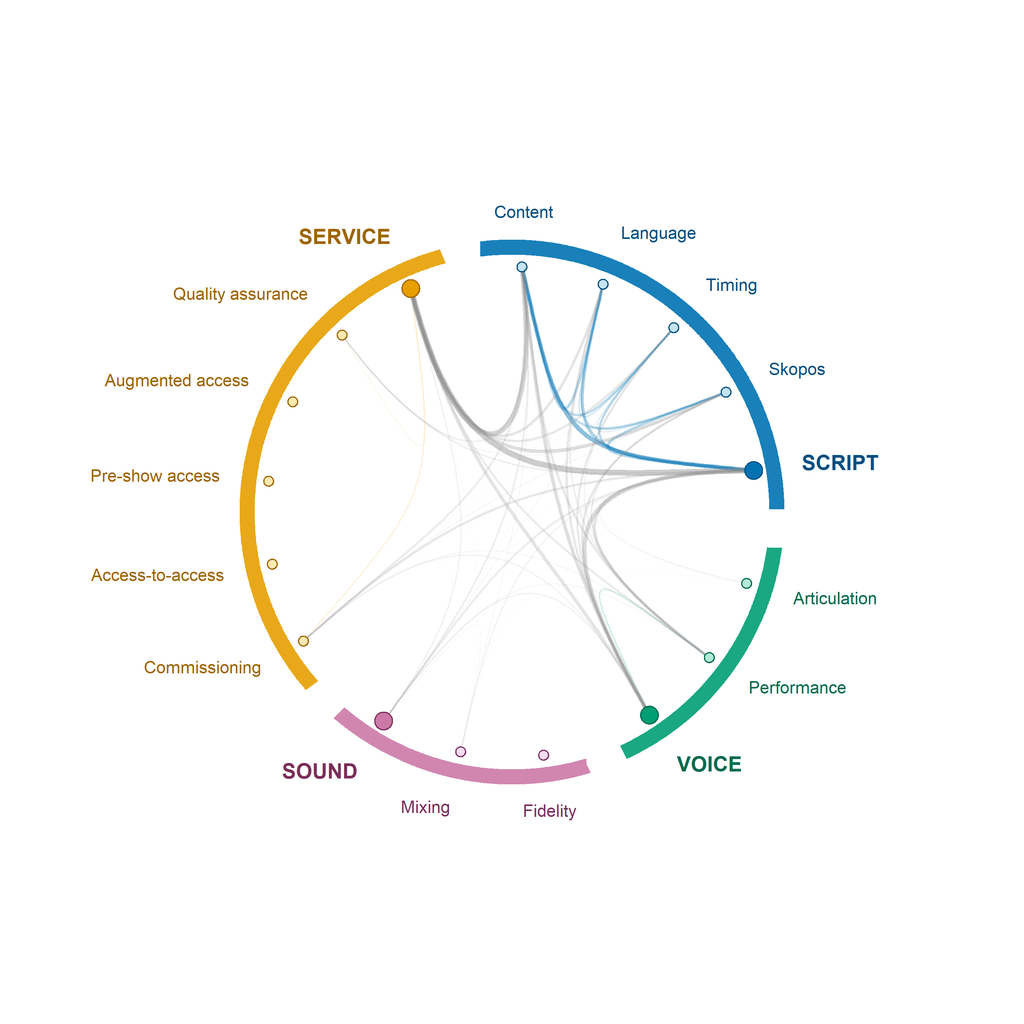

```r
fig7 <- ggplot() +
  # Within-dimension ribbons take the dimension's colour, drawn first.
  geom_path(
    data = bundles |> filter(same_parent) |> arrange(from, to, t),
    aes(x = x, y = y, group = interaction(from, to),
        colour    = I(alpha(DIM_SAT[from_parent],
                            rescale(weight, to = c(0.05, 0.45)))),
        linewidth = I(rescale(weight, to = c(0.20, 1.60)))),
    lineend = "round", show.legend = FALSE
  ) +
  # Cross-dimension ribbons are grey, so colour never implies a dimension
  # for a link that spans two.
  geom_path(
    data = bundles |> filter(!same_parent) |> arrange(from, to, t),
    aes(x = x, y = y, group = interaction(from, to),
        colour    = I(alpha("#888888", rescale(weight, to = c(0.06, 0.42)))),
        linewidth = I(rescale(weight, to = c(0.20, 2.20)))),
    lineend = "round", show.legend = FALSE
  ) +
  geom_path(data = arc_overlays,
            aes(x = x, y = y, group = parent, colour = I(DIM_SAT[parent])),
            linewidth = 5.5, lineend = "butt", alpha = 0.90, show.legend = FALSE) +
  geom_circle(
    data = node_pos,
    aes(x0 = x, y0 = y,
        r      = if_else(is_parent, 0.036, 0.020),
        fill   = I(if_else(is_parent, DIM_SAT[parent], DIM_LITE[parent])),
        colour = I(DIM_DARK[parent])),
    linewidth = 0.5, show.legend = FALSE
  ) +
  geom_text(data = filter(node_pos, is_parent),
            aes(x = x_lab, y = y_lab, label = label, hjust = hjust, vjust = vjust,
                colour = I(DIM_DARK[parent])),
            size = BASE_F7 * 0.44, fontface = "bold", family = FONT,
            show.legend = FALSE) +
  geom_text(data = filter(node_pos, !is_parent),
            aes(x = x_lab, y = y_lab, label = label, hjust = hjust, vjust = vjust,
                colour = I(DIM_DARK[parent])),
            size = BASE_F7 * 0.36, fontface = "plain", family = FONT,
            show.legend = FALSE) +
  coord_equal(xlim = c(-1.85, 1.85), ylim = c(-1.85, 1.85), clip = "off") +
  theme_void(base_size = BASE_F7, base_family = FONT) +
  theme(plot.background = element_rect(fill = "white", colour = NA),
        plot.margin = margin(10, 10, 10, 10))

save_figure(fig7, "Figure7", width = 11, height = 11)
fig7
```

# Figure 8 — Who evaluates AD quality?

Evaluator groups across the corpus. Each bubble is one human evaluator group: how many studies used it (horizontal), the mean sample it reported (vertical), and the total number of people it accounts for (area).

Three conventions matter for reading the numbers. First, there are two human groups, not three: researchers, producers and other non-BPS human raters are counted in the sighted sample-size column rather than in a separate “other” group. Second, membership and size are recorded separately, and a study joins a group if *either* its evaluator labels name that group *or* its group-specific sample size is above zero — the two evaluator slots cannot hold every group a study used. The undifferentiated `[PAR] Evaluator Sample Size` column, which reports a study’s overall total, is never redistributed; instead the code checks that it equals BPS plus sighted and stops if it does not. Third, a study is counted once per group, so a study using both blind and sighted evaluators appears in both without its participants being double-counted.

Machine evaluators take part in the membership counts — by evaluator label or by an `Automatic` entry in the quality-assessment columns — but have no participants to sum, so they are not plotted.

The dashed outline shows where the sighted group would sit without its three largest samples, which is the honest way to show that its mean is carried by a small number of crowdsourced studies. The layout is measured rather than guessed: bubble radii and label boxes are computed in millimetres and the axis limits are solved so that everything fits inside the panel with nothing clipped.

Three CSVs are written alongside the figure: the group summary, the study-level memberships, and an audit of rows where the evaluator labels and the recorded counts disagree.

```r
BASE_F8 <- 12

EMPIRICAL_ONLY <- FALSE   # TRUE restricts the figure to empirical studies
SHOW_TRIMMED   <- TRUE    # dashed outline: sighted group without its largest samples
TRIM_K         <- 3       # how many of the largest sighted samples to set aside
MAX_BUBBLE     <- 80      # point size of the largest bubble; areas stay proportional

EVAL_GROUPS   <- c("Blind & partially sighted", "Sighted")
GROUP_PALETTE <- setNames(c(DIM_SAT[["SCRIPT"]], DIM_SAT[["SERVICE"]]), EVAL_GROUPS)

COL <- list(
  author = "[BIB] Author(s)", year = "[BIB] Publication Year",
  discipline = "[BIB] Discipline", type = "[MET] Study Type",
  qa1 = "[MET] Quality Assessment 1", qa2 = "[MET] Quality Assessment 2",
  ev1 = "[PAR] Evaluator 1", ev2 = "[PAR] Evaluator 2",
  n_all = "[PAR] Evaluator Sample Size",
  n_bps = "[PAR] Evaluator Sample Size (BPS)",
  n_sig = "[PAR] Evaluator Sample Size (Sighted)")

# Evaluator labels and the group each belongs to. An unknown label stops the
# script rather than being silently dropped.
label_map <- c(
  "Blind and partially sighted" = "Blind & partially sighted",
  "Sighted (professional)"      = "Sighted",
  "Sighted (non-professional)"  = "Sighted",
  "Researcher"                  = "Sighted",
  "Producer"                    = "Sighted",
  "Autistic"                    = "Sighted",
  "Dyslexic"                    = "Sighted",
  "Machine"                     = "Machine",
  "Machine (model-based)"       = "Machine",
  "Machine (reference-based)"   = "Machine")

evaluators_raw <- studies |> mutate(study_id = row_number())
stopifnot(all(unlist(COL) %in% names(evaluators_raw)))

# Counts must be non-negative whole numbers; anything else is a data error
# rather than something to coerce quietly.
to_count <- function(x) {
  n <- suppressWarnings(as.numeric(x))
  unparsed <- !is.na(x) & !(trimws(as.character(x)) %in% c("", "NA")) & is.na(n)
  if (any(unparsed)) stop("Non-numeric value in an evaluator sample-size column.")
  if (any(!is.na(n) & (n < 0 | n != floor(n)))) {
    stop("Evaluator counts must be non-negative integers.")
  }
  n
}
na_text <- function(x) {
  if_else(trimws(as.character(x)) %in% c("", "NA"),
          NA_character_, trimws(as.character(x)))
}

evaluators_raw <- evaluators_raw |>
  mutate(across(all_of(c(COL$n_all, COL$n_bps, COL$n_sig)), to_count),
         across(all_of(c(COL$ev1, COL$ev2, COL$qa1, COL$qa2)), na_text))

split_ok <- is.na(evaluators_raw[[COL$n_all]]) |
  evaluators_raw[[COL$n_all]] == coalesce(evaluators_raw[[COL$n_bps]], 0) +
  coalesce(evaluators_raw[[COL$n_sig]], 0)
if (!all(split_ok)) {
  stop("Total sample size differs from BPS + Sighted in rows: ",
       paste(evaluators_raw$study_id[!split_ok], collapse = ", "))
}

labels_used <- unique(na.omit(c(evaluators_raw[[COL$ev1]], evaluators_raw[[COL$ev2]])))
unknown <- setdiff(labels_used, names(label_map))
if (length(unknown)) stop("Unmapped evaluator label(s): ", paste(unknown, collapse = "; "))

if (EMPIRICAL_ONLY) evaluators_raw <- evaluators_raw |> filter(.data[[COL$type]] == "Empirical")

# ---- Group membership -------------------------------------------------------
flags <- evaluators_raw |>
  transmute(
    study_id,
    lab_bps  = label_map[coalesce(.data[[COL$ev1]], "")] %in% EVAL_GROUPS[1] |
      label_map[coalesce(.data[[COL$ev2]], "")] %in% EVAL_GROUPS[1],
    lab_sig  = label_map[coalesce(.data[[COL$ev1]], "")] %in% EVAL_GROUPS[2] |
      label_map[coalesce(.data[[COL$ev2]], "")] %in% EVAL_GROUPS[2],
    lab_mach = label_map[coalesce(.data[[COL$ev1]], "")] %in% "Machine" |
      label_map[coalesce(.data[[COL$ev2]], "")] %in% "Machine",
    qa_auto  = coalesce(.data[[COL$qa1]] == "Automatic", FALSE) |
      coalesce(.data[[COL$qa2]] == "Automatic", FALSE),
    n_bps = .data[[COL$n_bps]], n_sig = .data[[COL$n_sig]],
    is_bps  = lab_bps | coalesce(n_bps, 0) > 0,
    is_sig  = lab_sig | coalesce(n_sig, 0) > 0,
    is_mach = lab_mach | qa_auto)

ev <- bind_rows(
  flags |> filter(is_bps) |>
    transmute(study_id, EvalGroup = EVAL_GROUPS[1],
              sample_n = if_else(coalesce(n_bps, 0) > 0, n_bps, NA_real_)),
  flags |> filter(is_sig) |>
    transmute(study_id, EvalGroup = EVAL_GROUPS[2],
              sample_n = if_else(coalesce(n_sig, 0) > 0, n_sig, NA_real_)),
  flags |> filter(is_mach) |>
    transmute(study_id, EvalGroup = "Machine", sample_n = NA_real_))

# ---- Audit: rows where labels and counts disagree ---------------------------
audit <- flags |>
  mutate(issue = pmap_chr(list(
    if_else(coalesce(n_bps, 0) > 0 & !lab_bps, "BPS count without BPS label", NA_character_),
    if_else(coalesce(n_sig, 0) > 0 & !lab_sig, "Sighted count without sighted-side label", NA_character_),
    if_else(lab_bps & is.na(n_bps), "BPS label without count", NA_character_),
    if_else(lab_sig & is.na(n_sig), "Sighted-side label without count", NA_character_),
    if_else(qa_auto & !lab_mach, "Automatic QA without machine label", NA_character_)),
    ~ paste(na.omit(c(...)), collapse = "; "))) |>
  filter(issue != "") |>
  left_join(evaluators_raw |> select(study_id, all_of(c(COL$author, COL$year, COL$ev1, COL$ev2))),
            by = "study_id")
if (nrow(audit)) {
  message(nrow(audit), " study row(s) where labels and counts disagree; see Figure8_audit.csv")
}

# ---- Summaries --------------------------------------------------------------
summarise_group <- function(d) d |> summarise(
  n_studies     = n_distinct(study_id),
  n_with_sample = sum(!is.na(sample_n)),
  total_n  = if (all(is.na(sample_n))) NA_real_ else sum(sample_n, na.rm = TRUE),
  mean_n   = if (all(is.na(sample_n))) NA_real_ else mean(sample_n, na.rm = TRUE),
  median_n = if (all(is.na(sample_n))) NA_real_ else median(sample_n, na.rm = TRUE),
  .groups = "drop")

evaluator_summary <- ev |> group_by(EvalGroup) |> summarise_group() |>
  mutate(EvalGroup = factor(EvalGroup, levels = c(EVAL_GROUPS, "Machine"))) |>
  arrange(EvalGroup)
stopifnot(is.na(evaluator_summary$total_n[evaluator_summary$EvalGroup == "Machine"]))

any_evaluator <- n_distinct(ev$study_id)
both_human    <- sum(flags$is_bps & flags$is_sig)

largest <- ev |> filter(EvalGroup == EVAL_GROUPS[2], !is.na(sample_n)) |>
  slice_max(sample_n, n = TRIM_K, with_ties = FALSE)
trimmed <- ev |> filter(EvalGroup == EVAL_GROUPS[2], !study_id %in% largest$study_id) |>
  summarise_group() |>
  mutate(EvalGroup = paste0(EVAL_GROUPS[2], " (without ", TRIM_K, " largest)"))

knitr::kable(bind_rows(mutate(evaluator_summary, EvalGroup = as.character(EvalGroup)), trimmed),
             digits = 1, caption = "Evaluator groups across the corpus")
```

Evaluator groups across the corpus

| EvalGroup | n_studies | n_with_sample | total_n | mean_n | median_n |
| --- | --- | --- | --- | --- | --- |
| Blind & partially sighted | 31 | 31 | 817 | 26.4 | 15.0 |
| Sighted | 35 | 33 | 1866 | 56.5 | 8.0 |
| Machine | 9 | 0 | NA | NA | NA |
| Sighted (without 3 largest) | 32 | 30 | 546 | 18.2 | 5.5 |

```r
write_csv(bind_rows(mutate(evaluator_summary, EvalGroup = as.character(EvalGroup)), trimmed) |>
            mutate(studies_with_any_evaluator = any_evaluator,
                   studies_with_both_human_groups = both_human,
                   empirical_only = EMPIRICAL_ONLY),
          file.path(FIG_DIR, "Figure8_summary.csv"), na = "")
write_csv(ev |>
            left_join(evaluators_raw |> select(study_id, all_of(c(COL$author, COL$year,
                                                                 COL$discipline, COL$type,
                                                                 COL$ev1, COL$ev2))),
                      by = "study_id") |>
            arrange(EvalGroup, desc(sample_n)),
          file.path(FIG_DIR, "Figure8_study_groups.csv"), na = "")
write_csv(audit, file.path(FIG_DIR, "Figure8_audit.csv"), na = "")
```

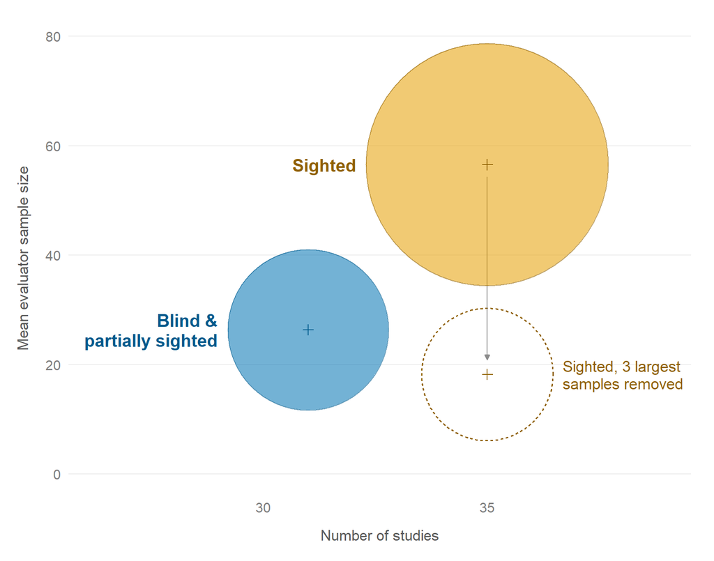

```r
W_F8 <- 7; H_F8 <- 5.5
GAP_MM <- 2.5   # space between a bubble and its name
PAD_MM <- 5     # breathing room between the outermost element and the panel edge
LH     <- .95   # label line height
BUBBLE_STROKE <- .5

DEV_FAMILY_F8 <- if (nzchar(FONT)) FONT else "sans"

# Darker tints for bubble outlines and names.
ink <- setNames(c("#005A8C", "#8F6000"), EVAL_GROUPS)

theme_bubble <- theme_minimal(base_size = BASE_F8, base_family = FONT) +
  theme(
    panel.grid         = element_blank(),
    panel.grid.major.y = element_line(colour = "grey93", linewidth = .3),
    axis.ticks   = element_blank(),
    axis.text    = element_text(size = 9.5, colour = "grey50"),
    axis.title   = element_text(size = 10.5, colour = "grey35"),
    axis.title.x = element_text(margin = margin(t = 10)),
    axis.title.y = element_text(margin = margin(r = 10)),
    plot.margin  = margin(16, 16, 12, 12),
    legend.position = "none"
  )

grp <- evaluator_summary |> filter(EvalGroup %in% EVAL_GROUPS, !is.na(mean_n)) |>
  mutate(EvalGroup = as.character(EvalGroup))
max_total <- max(grp$total_n)
bps <- filter(grp, EvalGroup == EVAL_GROUPS[1])
sig <- filter(grp, EvalGroup == EVAL_GROUPS[2])

els <- tibble(
  id    = c("bps", "sig", "trim"),
  x     = c(bps$n_studies, sig$n_studies, sig$n_studies),  # outline shares the sighted x
  y     = c(bps$mean_n, sig$mean_n, trimmed$mean_n),
  total = c(bps$total_n, sig$total_n, trimmed$total_n),
  label = c("Blind &\npartially sighted", "Sighted",
            sprintf("Sighted, %s largest\nsamples removed", TRIM_K)),
  face  = c("bold", "bold", "plain"), tsize = c(4.3, 4.3, 3.8),
  side  = c(-1, -1, 1),                                    # -1 = name left, 1 = right
  ink   = c(ink[[1]], ink[[2]], ink[[2]]))
if (!SHOW_TRIMMED || is.na(trimmed$mean_n)) els <- filter(els, id != "trim")

# Sizes measured in millimetres, on the same kind of device used for the output.
tmp_dev <- tempfile(fileext = ".pdf")
PDF_DEVICE(tmp_dev, width = W_F8, height = H_F8, family = DEV_FAMILY_F8)
els <- els |> mutate(
  r_mm = .75 * (MAX_BUBBLE * sqrt(total / max_total) * .pt +
                  BUBBLE_STROKE * .stroke / 2) / 2 / 72.27 * 25.4,
  w_mm = pmap_dbl(list(label, face, tsize), function(l, f, s)
    grid::convertWidth(grid::grobWidth(grid::textGrob(
      l, gp = grid::gpar(fontfamily = FONT, fontface = f,
                         fontsize = s * .pt, lineheight = LH))),
      "mm", valueOnly = TRUE)),
  h_mm = pmap_dbl(list(label, face, tsize), function(l, f, s)
    grid::convertHeight(grid::grobHeight(grid::textGrob(
      l, gp = grid::gpar(fontfamily = FONT, fontface = f,
                         fontsize = s * .pt, lineheight = LH))),
      "mm", valueOnly = TRUE)),
  left_mm  = r_mm + if_else(side < 0, GAP_MM + w_mm, 0),
  right_mm = r_mm + if_else(side > 0, GAP_MM + w_mm, 0),
  vert_mm  = pmax(r_mm, h_mm / 2))

make_base <- function(x_lim, y_lim) {
  ggplot() +
    scale_x_continuous(limits = x_lim, breaks = breaks_pretty(4),
                       expand = expansion(0)) +
    scale_y_continuous(limits = y_lim, breaks = breaks_pretty(4),
                       labels = comma, expand = expansion(0)) +
    coord_cartesian(clip = "off") +
    labs(x = "Number of studies", y = "Mean evaluator sample size") + theme_bubble
}
panel_size <- function(x_lim, y_lim) {
  g <- ggplotGrob(make_base(x_lim, y_lim) + geom_blank(aes(x = x_lim, y = y_lim)))
  c(W_F8, H_F8) * 25.4 - c(grid::convertWidth(sum(g$widths), "mm", valueOnly = TRUE),
                           grid::convertHeight(sum(g$heights), "mm", valueOnly = TRUE))
}
# Solve for the scale (mm per data unit) at which every element just fits.
fit_axis <- function(pos, lo_mm, hi_mm, span_mm, floor_at = NULL) {
  lims <- function(k) {
    lo <- min(pos - (lo_mm + PAD_MM) / k)
    if (!is.null(floor_at)) lo <- min(lo, floor_at - PAD_MM / k)
    c(lo, max(pos + (hi_mm + PAD_MM) / k))
  }
  f <- function(k) k * diff(lims(k)) - span_mm
  if (f(1e-6) >= 0) stop("Bubbles and names do not fit; lower MAX_BUBBLE or the label sizes.")
  lims(uniroot(f, c(1e-6, 1e4), tol = 1e-9)$root)
}
x_lim <- range(els$x) + c(-5, 5); y_lim <- c(0, max(els$y) * 1.5)
for (i in 1:3) {
  pm <- panel_size(x_lim, y_lim)
  x_lim <- fit_axis(els$x, els$left_mm, els$right_mm, pm[1])
  y_lim <- fit_axis(els$y, els$vert_mm, els$vert_mm, pm[2], floor_at = 0)
}
pm <- panel_size(x_lim, y_lim)
invisible(grDevices::dev.off()); unlink(tmp_dev)
kx <- pm[1] / diff(x_lim); ky <- pm[2] / diff(y_lim)   # mm per data unit

els <- els |> mutate(lab_x = x + side * (r_mm + GAP_MM) / kx,
                     hjust = if_else(side < 0, 1, 0))
fills <- els |> filter(id != "trim") |> arrange(desc(total)) |>
  mutate(group = if_else(id == "bps", EVAL_GROUPS[1], EVAL_GROUPS[2]))

fig8 <- make_base(x_lim, y_lim)

if ("trim" %in% els$id) {
  tr <- filter(els, id == "trim")
  ring <- tibble(t = seq(0, 2 * pi, length.out = 241)) |>
    mutate(x = tr$x + tr$r_mm / kx * cos(t), y = tr$y + tr$r_mm / ky * sin(t))
  fig8 <- fig8 +
    geom_path(data = ring, aes(x, y), colour = tr$ink, linewidth = .45,
              linetype = "22") +
    annotate("segment", x = tr$x, xend = tr$x,
             y = sig$mean_n - 3 / ky, yend = tr$y + 3.5 / ky,
             colour = "grey55", linewidth = .3,
             arrow = arrow(length = unit(1.5, "mm"), angle = 25, type = "closed"))
}

fig8 <- fig8 +
  geom_point(data = fills, aes(x, y, size = total, fill = group, colour = group),
             shape = 21, stroke = BUBBLE_STROKE, alpha = .55) +
  # Area, not radius, is proportional to the participant total.
  scale_size_area(max_size = MAX_BUBBLE, limits = c(0, max_total), guide = "none") +
  scale_fill_manual(values = GROUP_PALETTE) + scale_colour_manual(values = ink) +
  geom_point(data = els, aes(x, y), shape = 3, size = 2.2, stroke = .5,
             colour = els$ink) +
  geom_text(data = els, aes(lab_x, y, label = label, hjust = hjust), vjust = .5,
            family = FONT, fontface = els$face, size = els$tsize,
            lineheight = LH, colour = els$ink)

draw_fig8 <- function() print(fig8)
PDF_DEVICE(file.path(FIG_DIR, "Figure8.pdf"), width = W_F8, height = H_F8,
           family = DEV_FAMILY_F8)
draw_fig8(); invisible(grDevices::dev.off())
grDevices::png(file.path(FIG_DIR, "Figure8.png"), width = W_F8, height = H_F8,
               units = "in", res = 400, type = "cairo", bg = "white")
draw_fig8(); invisible(grDevices::dev.off())

message("Studies with any evaluator: ", any_evaluator,
        "; with both human groups: ", both_human)

fig8
```